# Project 2: Data Mining, Classification, Prediction

SDS332E

# Mining, Classification, Prediction

## Danielle Ramos UTEID: dcr2325

### Introduction

This project explores several methods of dsta mining, classification, and predictions using the “movies” dataset from the ggplot2movies built in R package. This dataset was developed from the movie database website http://imdb.com/, which is a frequently viewed website for movie fanatics like myself. This dataframe contains the ‘year’ the film was released, the ‘budget’ as the cost of the film production is USD, the ‘length’ of the movie in minutes, ‘rating’ average IMDB users, the ‘number’ of IMDB users who rated the movie,the ‘percentage’ (to the nearest 10%) of a 1 out of 10 rating, and the ‘mpaa’ variable that is the MPAA rating (PG, PG-13, R, etc.), and lastly an abundance of binary variables for the classification of the movie genre for 28,819 movies! Given that there are many binary variables in this data set, I specifically chose to explore the “Action” movie genre as the binary variable for classifications and predictions throughout the project. The “Action” genre specifically interested me based on the preconceived notion of action movies typically costing the most to make of all the other genres, the fact that from my experience they are also long films in length, and have franchise attachments which comes with a fan base (ie. Fast and Furious, The Avengers, Taken, Batman/ Dark Night, etc.) which could introduce biases in who is voting and rating these movies. This binary variable is represented in a numerical fashion with 0,1, and was also mutated for the PCA portion as a categorical variable “TRUE/FALSE”.

To prepare my data for initial mining, all of the NAs in my dataset were removed to provide greater clarity when clustering the data. The variables ‘r1-10’ were also removed from the datset, as those specific numerical variables were not informative for the what the goal of the predictions were, and created a wide data set overall. the ‘movies’ dataset is now ready for the cluster analysis.

```r
library(tidyverse)
library(ggplot2movies)

data(movies)
movies = na.omit(movies)
movies = movies %>% select(-7:-16)
dim(movies)
```

```
## [1] 5215   14
```

```r
head(movies)
```

```
## # A tibble: 6 x 14
##   title      year length budget rating votes mpaa  Action Animation Comedy Drama
##   <chr>     <int>  <int>  <int>  <dbl> <int> <chr>  <int>     <int>  <int> <int>
## 1 'G' Men    1935     85  4.5e5    7.2   281 ""         0         0      0     1
## 2 'Manos' …  1966     74  1.9e4    1.6  7996 ""         0         0      0     0
## 3 'Til The…  1997    113  2.3e7    4.8   799 "PG-…      0         0      1     0
## 4 .com for…  2002     96  5  e6    3.7   271 ""         0         0      0     0
## 5 10 Thing…  1999     97  1.6e7    6.7 19095 "PG-…      0         0      1     0
## 6 100 Mile…  2002     98  1.1e6    5.6   181 "R"        0         0      1     0
## # … with 3 more variables: Documentary <int>, Romance <int>, Short <int>
```

```r
# removing all NA values and numeric values that hold no
# value to the project
```

### Cluster Analysis

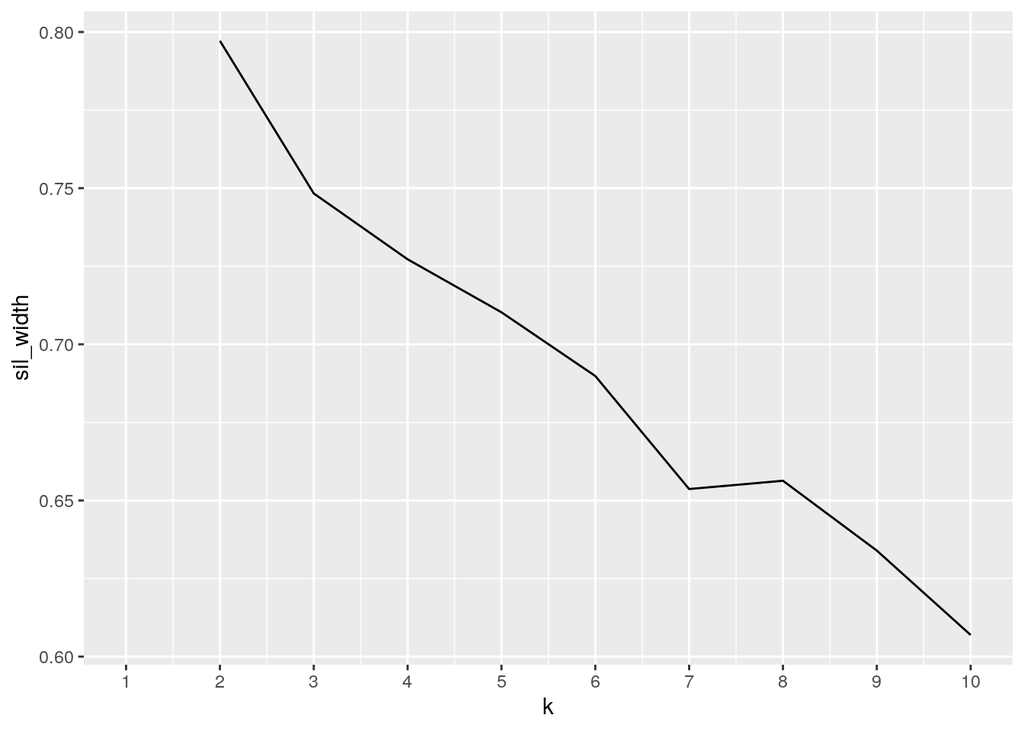

```r
library(cluster)
num_dat <- select(movies, (3:6))

sil_width <- vector()
for (i in 2:10) {
    kms <- kmeans(num_dat, centers = i)
    sil <- silhouette(kms$cluster, dist(num_dat))
    sil_width[i] <- mean(sil[, 3])
}
ggplot() + geom_line(aes(x = 1:10, y = sil_width)) + scale_x_continuous(name = "k",
    breaks = 1:10)
```

```r
# k = 2!

pam1 <- num_dat %>% pam(k = 2)  #use the pam function
pam1
```

```
## Medoids:
##        ID length   budget rating votes
## [1,] 3280     92  1250000    7.0  1459
## [2,] 3608    123 45000000    6.9  9852
## Clustering vector:
##   [1] 1 1 1 1 1 1 1 1 1 2 1 1 1 2 2 2 2 1 1 2 2 1 1 1 1 1 1 2 1 1 1 1 1 2 1 1 1
##  [38] 1 2 1 1 1 1 1 2 2 1 1 2 1 1 2 1 2 1 1 1 1 2 2 1 1 1 1 1 1 1 2 2 1 1 2 1 2
##  [75] 1 1 1 2 1 1 1 1 1 1 1 2 1 1 2 1 1 1 1 1 1 2 2 1 2 1
##  [ reached getOption("max.print") -- omitted 5115 entries ]
## Objective function:
##   build    swap
## 7191656 7007293
##
## Available components:
##  [1] "medoids"    "id.med"     "clustering" "objective"  "isolation"
##  [6] "clusinfo"   "silinfo"    "diss"       "call"       "data"
```

```r
pamclust <- num_dat %>% mutate(cluster = as.factor(pam1$clustering))
pamclust %>% group_by(cluster) %>% summarize_if(is.numeric, mean,
    na.rm = TRUE)
```

```
## # A tibble: 2 x 5
##   cluster length    budget rating  votes
##   <fct>    <dbl>     <dbl>  <dbl>  <dbl>
## 1 1         91.3  4163589.   6.15  2907.
## 2 2        116.  53330907.   6.09 13898.
```

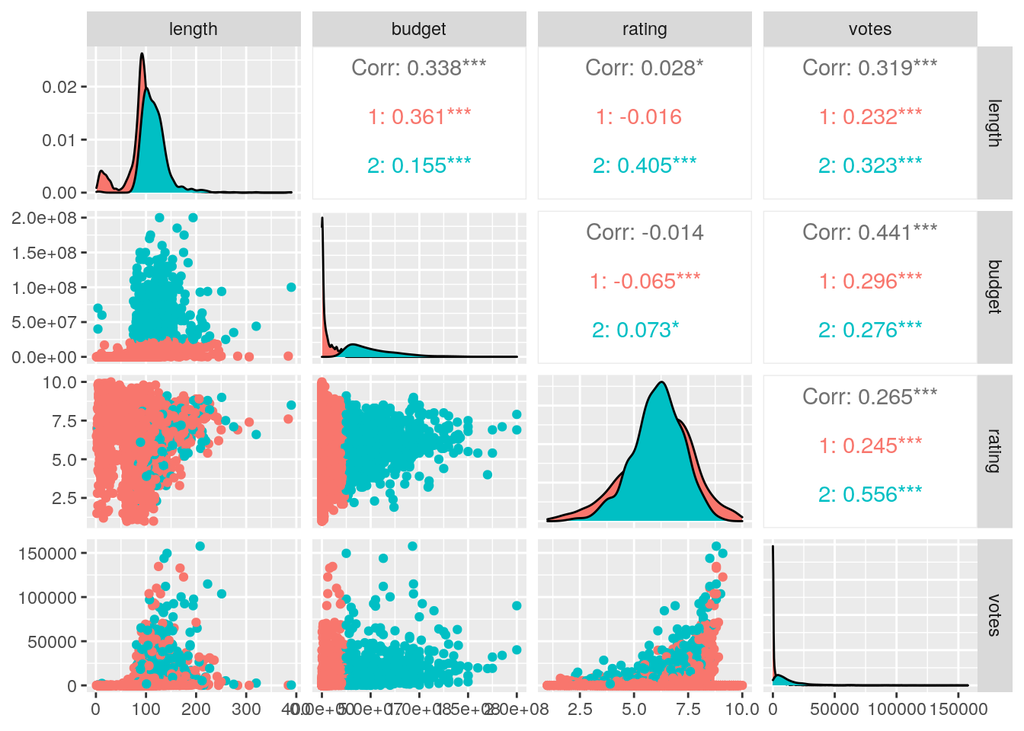

```r
library(GGally)
ggpairs(pamclust, columns = 1:4, aes(color = cluster))
```

[figure not shown]

```r
plot(pam1, which = 2)
```

```r
# Sillhouette plot is blank due to such a large number of
# observations, but the average width is accurate and
# displayed!
```

To initialize the cluster analysis, it was found that two clusters were ideal for this solution, as the silhouette width was calculate to make k=2. The two clusters were created using the pam function and the results yielded cluster 2 having the highest average values for ‘length’, ‘budget’, and ‘votes’, making the cluster 1 have the highest average value only for ‘rating’.The cluster solution strength was determined by the average silhouette width, which came out to be 0.77, which is relatively strong, and substantial for the visualization of the clusters. According to the visualizations shown in the ‘ggpairs’ plot, the most similar cluster distributions are shown among the ‘length’ and ‘rating’ variables, as cluster 2 (blue) represents a normal distribution. Likewise, the cluster distributions for budget and votes are extremely similar in that while the second cluster reveals some normality, the mean values in the y axis are much less than the ‘length’ and ‘rating’ clusters.

### Dimensionality Reduction with PCA

```r
# making a PCA
pca1 <- princomp(num_dat, cor = T)
names(pca1)
```

```
## [1] "sdev"     "loadings" "center"   "scale"    "n.obs"    "scores"   "call"
```

```r
summary(pca1, loadings = T)
```

```
## Importance of components:
##                           Comp.1    Comp.2    Comp.3    Comp.4
## Standard deviation     1.3309480 1.0275422 0.8330126 0.6919713
## Proportion of Variance 0.4428557 0.2639607 0.1734775 0.1197061
## Cumulative Proportion  0.4428557 0.7068164 0.8802939 1.0000000
##
## Loadings:
##        Comp.1 Comp.2 Comp.3 Comp.4
## length  0.509  0.275  0.815
## budget  0.568  0.309 -0.480  0.593
## rating  0.217 -0.888  0.150  0.376
## votes   0.610 -0.200 -0.287 -0.711
```

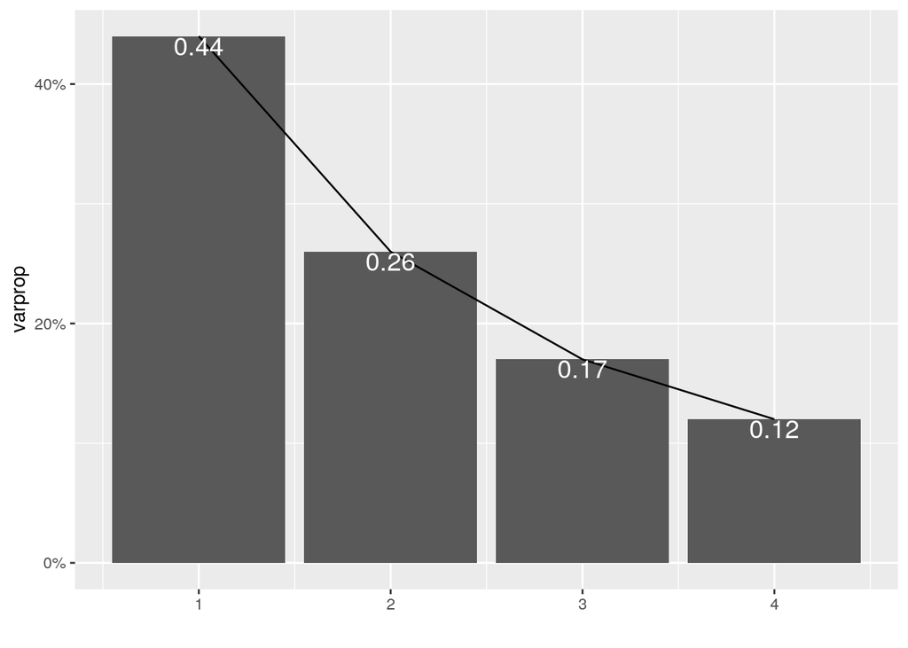

```r
# determining how many PCs are kept
eigval <- pca1$sdev^2
varprop = round(eigval/sum(eigval), 2)

ggplot() + geom_bar(aes(y = varprop, x = 1:4), stat = "identity") +
    xlab("") + geom_path(aes(y = varprop, x = 1:4)) + geom_text(aes(x = 1:4,
    y = varprop, label = round(varprop, 2)), vjust = 1, col = "white",
    size = 5) + scale_y_continuous(breaks = seq(0, 0.6, 0.2),
    labels = scales::percent) + scale_x_continuous(breaks = 1:10)
```

```r
# PC1 & PC2 are kept, as PC3 equated to 88% which is greater
# than the 85% threshold
round(cumsum(eigval)/sum(eigval), 2)
```

```
## Comp.1 Comp.2 Comp.3 Comp.4
##   0.44   0.71   0.88   1.00
```

```r
eigval
```

```
##    Comp.1    Comp.2    Comp.3    Comp.4
## 1.7714227 1.0558430 0.6939100 0.4788243
```

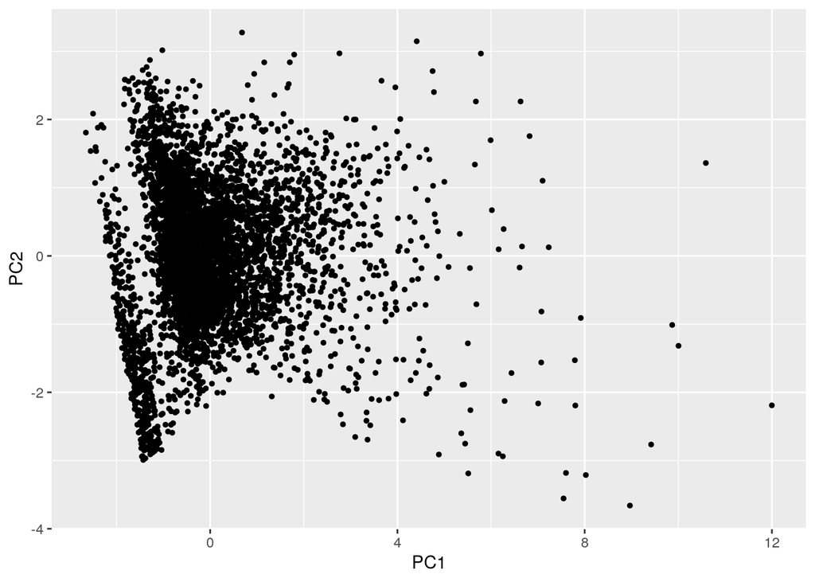

```r
num_dat_df <- data.frame(PC1 = pca1$scores[, 1], PC2 = pca1$scores[,
    2])
gg = ggplot(num_dat_df, aes(x = PC1, y = PC2)) + geom_point(size = 1)
print(gg)
```

The principal component analysis was run using the ‘num_dat’ data set containing the numerical variables length, budget, rating, and votes to further understand the correlations amongst each variable, while gaining in sight on the collective variability throughout the data by plotting a the PCA by PC1 and PC2. In order to determining how many PCs there should be, the ‘eigval’ was calculated, which yields the proportion of variance among the four components that were based on each of the variables in ‘num_dat’.The eigvals for the first two components were greater than 1, favoring 2 PCs being used for the PCA. The first two components summed up to 71 percent for the cumulative proportion of variance, and the first 3 summed up to 88 percent, making the first two components best for the PCA plot. As shown in the plot, PC1 and PC2 collectively explain 71% of the variability across all the variables from ‘num_dat’, which are ‘length’, ‘budget’, ‘rating’, and ‘votes’.

### Linear Classifier

```r
fit <- glm(Action ~ length + budget + rating + votes, data = movies,
    family = "binomial")

summary(fit)
```

```
##
## Call:
## glm(formula = Action ~ length + budget + rating + votes, family = "binomial",
##     data = movies)
##
## Deviance Residuals:
##     Min       1Q   Median       3Q      Max
## -2.9878  -0.5755  -0.4614  -0.3631   2.6725
##
## Coefficients:
##               Estimate Std. Error z value Pr(>|z|)
## (Intercept) -1.131e+00  1.989e-01  -5.689 1.28e-08 ***
## length       4.073e-03  1.440e-03   2.828  0.00468 **
## budget       2.450e-08  1.637e-09  14.962  < 2e-16 ***
## rating      -2.481e-01  2.901e-02  -8.554  < 2e-16 ***
## votes        1.781e-05  3.423e-06   5.201 1.98e-07 ***
## ---
## Signif. codes:  0 '***' 0.001 '**' 0.01 '*' 0.05 '.' 0.1 ' ' 1
##
## (Dispersion parameter for binomial family taken to be 1)
##
##     Null deviance: 4597.7  on 5214  degrees of freedom
## Residual deviance: 4074.7  on 5210  degrees of freedom
## AIC: 4084.7
##
## Number of Fisher Scoring iterations: 5
```

```r
score <- predict(fit, type = "response")
score %>% round(3)
```

[output not shown]

```r
class_diag(score, truth = movies$Action, positive = 1)
```

```
##            acc   sens   spec    ppv     f1     ba    auc
## Metrics 0.8506 0.1456 0.9856 0.6595 0.2385 0.5656 0.7209
```

```r
# summary(fit$fitted.values)


probability <- predict(fit, type = "response")
table(truth = movies$Action, prediction = as.numeric(probability >
    0.5)) %>% addmargins
```

```
##      prediction
## truth    0    1  Sum
##   0   4314   63 4377
##   1    716  122  838
##   Sum 5030  185 5215
```

```r
# specificity
4313/4377
```

```
## [1] 0.9853781
```

```r
# True Positive Rate
123/838
```

```
## [1] 0.146778
```

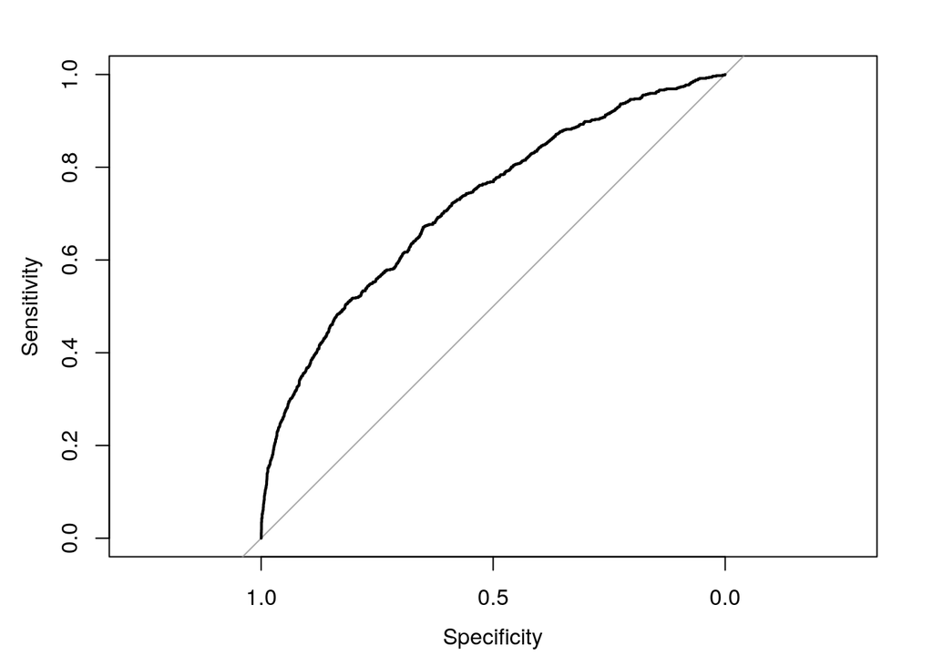

```r
library(pROC)
ROCplot <- plot.roc(movies$Action ~ probability)
```

```r
# cross validation

set.seed(1234)
k = 10

randomized <- movies[sample(nrow(movies)), ]
folds <- cut(seq(1:nrow(movies)), breaks = k, labels = F)

# trained model to data set
diags <- NULL
for (i in 1:k) {
    train = randomized[folds != i, ]
    test = randomized[folds == i, ]
    truth = test$Action
    fit <- glm(Action ~ length + budget + rating + votes, data = movies,
        family = "binomial")

    probs <- predict(fit, newdata = test, type = "response")

    diags <- rbind(diags, class_diag(probs, truth, positive = 1))
}

summarize_all(diags, mean)
```

```
##      acc    sens    spec     ppv      f1      ba     auc
## 1 0.8506 0.14656 0.98562 0.66688 0.23833 0.56609 0.72068
```

### Non-Parametric Classifier

```r
library(caret)
fit <- knn3(Action ~ length + budget + rating + votes, data = movies)
probability <- predict(fit, newdata = movies)[, 2]
class_diag(probability, movies$Action, positive = "1")
```

```
##            acc   sens   spec    ppv     f1     ba    auc
## Metrics 0.8652 0.2924 0.9749 0.6901 0.4107 0.6336 0.8697
```

```r
table(truth = movies$Action, prediction = as.numeric(probability >
    0.5)) %>% addmargins
```

```
##      prediction
## truth    0    1  Sum
##   0   4267  110 4377
##   1    593  245  838
##   Sum 4860  355 5215
```

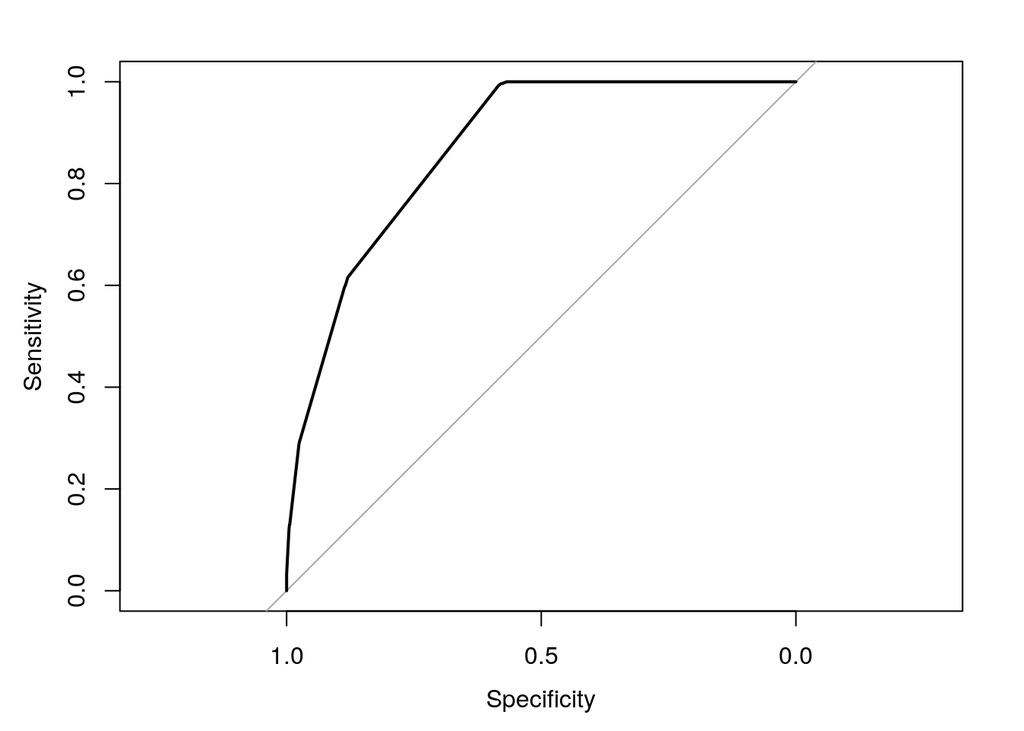

```r
ROCprob <- plot.roc(movies$Action ~ probability)
```

```r
# cross-validation of np classifier here
set.seed(1234)
k = 10
data <- randomized[sample(nrow(movies)), ]
folds_num <- cut(seq(1:nrow(movies)), breaks = k, labels = F)

diags <- NULL
for (i in 1:k) {
    train <- data[folds_num != i, ]
    test <- data[folds_num == i, ]
    truth <- test$Action


    fit <- knn3(Action ~ length + budget + rating + votes, data = movies)
    probability <- predict(fit, newdata = test)[, 2]


    diags <- rbind(diags, class_diag(probability, truth, positive = 1))
}

summarize_all(diags, mean)
```

```
##       acc    sens   spec     ppv      f1      ba     auc
## 1 0.86519 0.29314 0.9749 0.69045 0.41032 0.63402 0.87005
```

The non - parametric classification that was used was the K - nearest neighbor technique in order to predict if the movie reviewed was of the action genre or not based on the length, budget, rating, and votes for the movie. This classification yielded much better results than the linear classification done prior as the AUC value rose to 0.8697, which is an significant increase from the AUC value of 0.72068. This means the in- sample assessment without the influence of set conditions such as mean, standard deviation, variance, etc. of this classification yielded a better prediction of the outcome of the binary variable, Action, based on length, budget, rating, and votes. This improved outcome is adequately demonstrated in the ROC plot as the curve approaches the top left corner of the plane much more than the previous ROC plot, indicating an increased accuracy of this classification. To further validate this notion, a cross validation was performed, and the AUC value increased slightly to .87005, which overall concludes that this non-parametric model did a pretty good job at predicting the effects of the action movie genre predictor. However, because of this increase of the AUC value in the cross-validation, this could be a sign of overfitting.

### Regression/Numeric Prediction

```r
# regression model code here
fit <- lm(rating ~ length + budget, data = randomized)
yhat <- predict(fit)
mean((randomized$rating - yhat)^2)
```

```
## [1] 2.389356
```

```r
set.seed(1234)
k = 5
data <- randomized[sample(nrow(randomized)), ]
folds <- cut(seq(1:nrow(randomized)), breaks = k, labels = F)  #create folds
diags <- NULL
for (i in 1:k) {
    train <- data[folds != i, ]
    test <- data[folds == i, ]
    fit <- lm(rating ~ length + budget, data = randomized)
    yhat <- predict(fit, newdata = test)
    diags <- mean((randomized$rating - yhat)^2)
}
mean(diags)
```

```
## [1] 2.397256
```

### Python

```r
library(reticulate)
use_python("/usr/bin/python3", required = F)
who <- "Danielle Ramos"
```

```python
who = r.who
finals = "is done with finals!"
print(r.who,finals)
```

```
## Danielle Ramos is done with finals!
```

The python code above what integrated in to R using the ‘reticulate’ package which essentially allows for python and r to interact using syntax that favors python. In this simple example shown above, I created a string named “who” that contains my name, which is the subject of the sentence I created. The next chunk of code allows for the r-defined “who” string to be accessed in python. Now that this is accessed, I added the predicate of my sentence in a separate frame through python, and using the “print” statement, was able to combine the two strings to form the sentence “Danielle Ramos is done with finals!” because after I submit this, I will be!

### Concluding Remarks

This project allowed me to access a data set I have been wanting to explore since before I began project 1, because I really enjoy how much can be done with movie rating data, as an opinionated movie watcher like myself.While the coding delve in to concepts that, at first I struggled with, I was able to enjoy it and understand it more with this data set, particularly because of its usability with binary variables in relation to the topics in this project. In the future, I would like to further explore the use of R in conjunction with python and play with this interaction between the two and gather more sophisticated findings.